# Group 1 Week 5 assignment

- Show All Code
- Hide All Code
- View Source

Author

Affiliation

Rohit Satyam

King Abdullah University of Science & Technology, SA

# Question

Load, filter and normalize the GEX data and compare them to the matrix of the Gene Activity matrix inferred from ATAC. Comment on the most variable genes per cell type. Are there differences, why? Data: Multiome

*Response:* In this report we will go step by step and in the end will show how divergent is the RNASeq matrix imputed by using ATACSeq data and discuss our insights in the last section.

## Loading Libraries

```r
#options(width = 210)
library(Seurat)
library(TFBSTools)
library(motifmatchr)
library(Signac)
library(ggplot2)
library(Azimuth)
library(EnsDb.Mmusculus.v79)
library(BSgenome.Mmusculus.UCSC.mm10)
library(JASPAR2020)
library(chromVAR)
library('ggseqlogo')
```

## Loading the data

We procured Single Cell Multiome ATAC + Gene Expression data for 5K nuclei obtained from Mouse brain. More information about the data can be obtained at 10X website here. We first download data using `wget`

```
wget https://cf.10xgenomics.com/samples/cell-arc/2.0.2/M_Brain_Chromium_Nuc_Isolation_vs_SaltyEZ_vs_ComplexTissueDP/M_Brain_Chromium_Nuc_Isolation_vs_SaltyEZ_vs_ComplexTissueDP_filtered_feature_bc_matrix.tar.gz
wget https://cf.10xgenomics.com/samples/cell-arc/2.0.2/M_Brain_Chromium_Nuc_Isolation_vs_SaltyEZ_vs_ComplexTissueDP/M_Brain_Chromium_Nuc_Isolation_vs_SaltyEZ_vs_ComplexTissueDP_atac_fragments.tsv.gz
wget https://cf.10xgenomics.com/samples/cell-arc/2.0.2/M_Brain_Chromium_Nuc_Isolation_vs_SaltyEZ_vs_ComplexTissueDP/M_Brain_Chromium_Nuc_Isolation_vs_SaltyEZ_vs_ComplexTissueDP_atac_fragments.tsv.gz.tbi

## and then unzip just the filtered_feature file using
tar -zxvf M_Brain_Chromium_Nuc_Isolation_vs_SaltyEZ_vs_ComplexTissueDP_filtered_feature_bc_matrix.tar.gz
```

Since our `Data` directory contains both scRNASeq and ATAC-Seq data, `Read10X` function will read both of them. This can be checked with `names(counts)` . For creating ATACseq assay, we use `CreateChromatinAssay` from signac package.

```r
#### Loading scRNASeq counts
# reading data as sparse matrix to save memory
counts <- Read10X("Data/filtered_feature_bc_matrix/")
names(counts)
# create a Seurat object containing the RNA adata
mouse_brain <- CreateSeuratObject(
  counts = counts[['Gene Expression']],
  assay = "RNA"
)

#### Loading scATAC-Seq counts
fragpath <- 'Data/M_Brain_Chromium_Nuc_Isolation_vs_SaltyEZ_vs_ComplexTissueDP_atac_fragments.tsv.gz'

# get gene annotations for hg38 as GRanges object and convert the chromosome into UCSC format.
annotation <- GetGRangesFromEnsDb(ensdb = EnsDb.Mmusculus.v79)
seqlevels(annotation) <- paste0('chr', seqlevels(annotation))

# we will limit our exploration to the peaks for standard chromosomes and subset them to remove peaks detected on scaffold peaks
atac_counts <- counts$Peaks
grange.counts <- StringToGRanges(rownames(atac_counts), sep = c(":", "-"))
grange.use <- seqnames(grange.counts) %in% standardChromosomes(grange.counts)
atac_counts <- atac_counts[as.vector(grange.use), ]

## Updating mouse_brain seurat object with new assay called ATAC
mouse_brain[["ATAC"]] <- CreateChromatinAssay(
  counts = atac_counts,
  sep = c(":", "-"),
  fragments = fragpath,
  annotation = annotation
)

saveRDS(mouse_brain,"mouse_brain.step1.rds")
```

Since the steps above are time consuming and will slow down the report knitting process, we will compute them and save at multiple points and stamp them like this eg: `mouse_brain.step1.rds`

## Performing standard QC

For our objective, we do not require QC but the code below is included should you choose to explore data quality. For ATACSeq, signac got it’s own QC function

```r
## scrnaseq QC
mouse_brain$mitoPct <- PercentageFeatureSet(mouse_brain, pattern = "^mt-")
mouse_brain$RPSPct  <- PercentageFeatureSet(object = mouse_brain, pattern = "^Rp[sl]")
mouse_brain$log10GenesPerUMI <- log10(mouse_brain$nFeature_RNA) / log10(mouse_brain$nCount_RNA)

## atacseq QC
DefaultAssay(mouse_brain) <- "ATAC"
mouse_brain <- NucleosomeSignal(mouse_brain)
mouse_brain <- TSSEnrichment(mouse_brain, fast=FALSE)
total_fragments <- CountFragments(fragments = fragpath)
rownames(total_fragments) <- total_fragments$CB
mouse_brain$fragments <- total_fragments[colnames(mouse_brain), "frequency_count"]
mouse_brain <- FRiP(object = mouse_brain, assay = 'ATAC', total.fragments = 'fragments')
mouse_brain$nucleosome_group <- ifelse(mouse_brain$nucleosome_signal > 4, 'NS > 4', 'NS < 4')
mouse_brain$high.tss <- ifelse(mouse_brain$TSS.enrichment > 3, 'High', 'Low')

## Filtering outlier cells. We filter cells with peaks greater than 100K and less than 1K (arbitrary cutoff)
mouse_brain <- subset(
  x = mouse_brain,
  subset = nCount_ATAC < 100000 &
    nCount_ATAC > 1000 &
    nCount_RNA < 25000 &
    nCount_RNA > 1000 &
    nucleosome_signal < 2 &
    TSS.enrichment > 1 &
    FRiP > 0.2
)
saveRDS(mouse_brain,"mouse_brain.step2.rds")
```

The filtering criteria subsets both RNA and ATAC assay and leaves 18099 usable cells.

### Processing each modality separately

We will perform Log Normalization on RNASeq assay, Find top 2K variable features, run PCA ans UMAP and perform clustering. We will then use `RunAzimuth` to perform reference based label transfer to single cells.

```r
## Run dimensionality reduction, clustering and labeling of cells using Azimuth
DefaultAssay(mouse_brain) <- "RNA"
mouse_brain <- NormalizeData(mouse_brain)
mouse_brain <- FindVariableFeatures(mouse_brain,
            selection.method = "vst",
            nfeatures = 2000)
mouse_brain <- ScaleData(mouse_brain)
mouse_brain <- RunPCA(mouse_brain)
mouse_brain <- RunUMAP(mouse_brain, dims=1:30,
                       reduction = "pca",
                       reduction.name = "rna_umap")

mouse_brain <- FindNeighbors(mouse_brain, dims = 1:30)
mouse_brain <- FindClusters(mouse_brain,
            resolution = 0.4,
            algorithm = 3,
            cluster.name="RNA_clusters_03")
mouse_brain <- Azimuth::RunAzimuth(mouse_brain,
            reference = "mousecortexref")
```

I see that `FindTopFeatures` was run before `RunTFIDF` and i don’t know if that will have some effect on downstream analysis.

```r
DefaultAssay(mouse_brain) <- "ATAC"
mouse_brain <- FindTopFeatures(mouse_brain, min.cutoff = 5)
mouse_brain <- RunTFIDF(mouse_brain)
mouse_brain <- RunSVD(mouse_brain)
mouse_brain <- RunUMAP(mouse_brain, dims=1:30,
                reduction = "lsi",
                reduction.name = "atac_umap")

saveRDS(mouse_brain,"mouse_brain.step3.rds")
p1 <- DimPlot(mouse_brain, group.by = "orig.ident", label = FALSE) + NoLegend() + ggtitle("ATAC")
DefaultAssay(mouse_brain)<-"RNA"
p2 <- DimPlot(mouse_brain, group.by = "predicted.subclass", label = TRUE) + NoLegend() + ggtitle("RNA")

p1 + p2
```

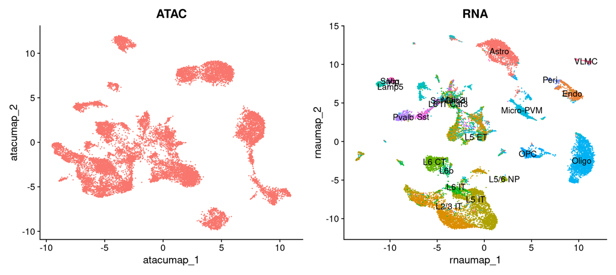

## Generating Gene Expression from ATAC-Seq

We want to see how good does ATACSeq guesses the expression of genes when compared to actual rnaseq data

```r
gene.activities <- GeneActivity(mouse_brain)
mouse_brain[['RNA_ACTIVITY']] <- CreateAssayObject(counts = gene.activities)
mouse_brain <- NormalizeData(
  object = mouse_brain,
  assay = 'RNA_ACTIVITY',
  normalization.method = 'LogNormalize',
  scale.factor = median(mouse_brain$nCount_RNA)
)
saveRDS(mouse_brain,"mouse_brain.step4.rds")
```

Now we will simple merge these RNA assay counts and RNA_ACTIVITY counts and visualise

```r
original <- CreateSeuratObject(counts = mouse_brain@assays$RNA$counts, project = "original", meta.data = mouse_brain@meta.data)

imputed <- CreateSeuratObject(counts = mouse_brain@assays$RNA_ACTIVITY$counts, project = "imputed")

imputed@meta.data$nFeature_RNA<-colSums(x = GetAssayData(object = imputed, slot = "counts") > 0)
imputed@meta.data$nCount_RNA<-colSums(x = imputed, slot = "counts")

imputed$log10GenesPerUMI <- log10(imputed$nFeature_RNA) / log10(imputed$nCount_RNA)

mb<- merge(x = original, y = imputed,
                   add.cell.ids = c("org", "imp"),
                   project = "mouseBrain")

## Observing number of genes detected in each cell (nFeature_RNA) and total number of molecules detected within a cell. (nCount_RNA)

VlnPlot(mb,
        features = c("nFeature_RNA", "nCount_RNA"),alpha = -1)
```

We observe that more genes are being observed as detected as compared to the original RNASeq samples and also more no. of molecules are detected per cell (see fig below).

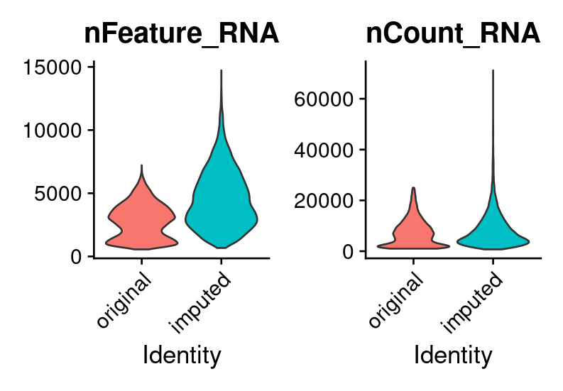

[figure not shown]

When we check correlation between the `nCount_RNA` and `nFeature_RNA` we see that there are imputed values for cells for which we do not have expression.

```r
## Performing normalization. This will normalize both the counts separately
mb <- NormalizeData(mb)
mb <- FindVariableFeatures(mb, selection.method = "vst", nfeatures = 2000)

DefaultAssay(mouse_brain)<-"RNA"
p1<-VariableFeaturePlot(mouse_brain)
p1<- LabelPoints(plot = p1, points = head(VariableFeatures(mouse_brain), 10), repel = TRUE)
p2<-VariableFeaturePlot(mb)
p2<- LabelPoints(plot = p2, points = head(VariableFeatures(mb), 10), repel = TRUE)
p1/p2

length(intersect(VariableFeatures(mb),VariableFeatures(mouse_brain)))

mb <- ScaleData(mb)
mb <- RunPCA(mb)
mb<-RunUMAP(mb, dims=1:30, reduction = "pca")
```

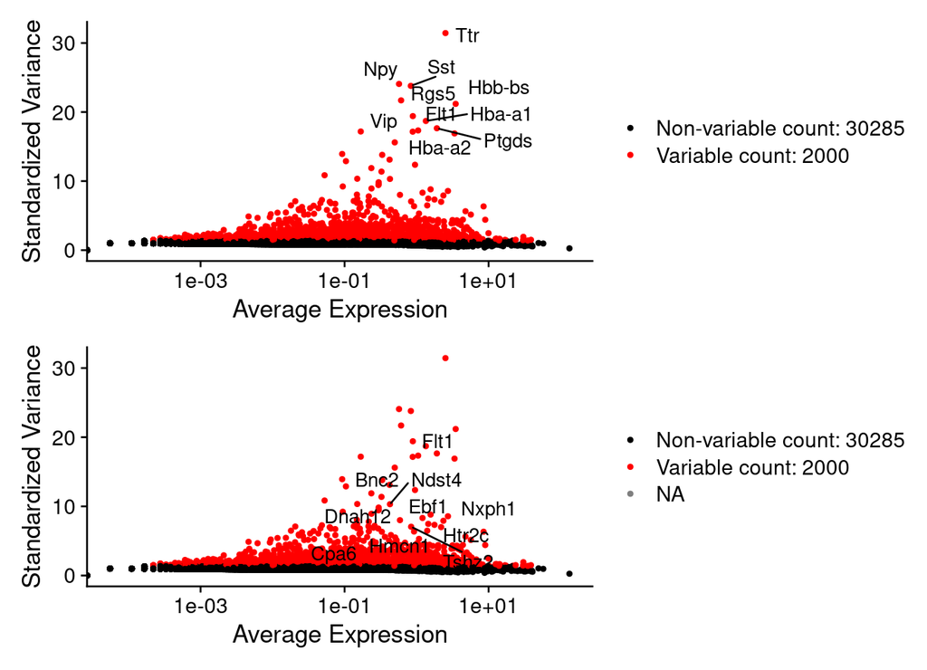

When compared the variable features not all features were same. However, we found that 63% of the features were common when compared to the original data.

We hypothesised that if the imputed expression values are closer to the actual values of the genes and the overall gene-expression repertoire of the cells matches with each other. Ideally they should behave like biological replicates and should not require integration and a simple merging of Seurat object and dimensionality reduction should ideally give us a fair overlap. But the PCA and UMAP below shows otherwise and we see that both RNAseq samples clusters separately.

```r
p1<-DimPlot(mb, reduction = "umap") + NoLegend()
p2<-DimPlot(mb, reduction = "pca") + NoLegend()
saveRDS(mb,"mb.step5.rds")
```

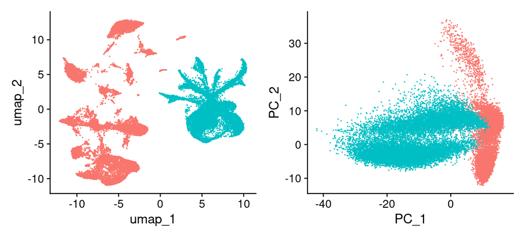

Next, we try to annotated the imputed data to see if the labels transferred by Azimuth matches with that of original labels. Surprisingly, only 6663 cells (~37%) of cells matches the classification. This means that expression values guessed by ATACSeq based method are too divergent.

```r
imputed<-imputed %>% NormalizeData() %>%  FindVariableFeatures(
            selection.method = "vst",
            nfeatures = 2000) %>% ScaleData() %>% RunPCA() %>% RunUMAP(dims=1:30,
                       reduction = "pca") %>% FindNeighbors(dims = 1:30) %>% FindClusters(      resolution = 0.4,
            algorithm = 3)

imputed <- Azimuth::RunAzimuth(imputed,
            reference = "mousecortexref")
table(colnames(imputed)==colnames(original))

df1<-as.data.frame(table(original$predicted.subclass))
df2<-as.data.frame(table(imputed$predicted.subclass))
df<-S4Vectors::merge(df1,df2,all=TRUE,by.x="Var1",by.y="Var1")
colnames(df)<- c("Predicted.Subclass","original","imputed")
df2<-reshape2::melt(df)
ggpubr::ggline(df2,x="Predicted.Subclass",y="value",group = "variable",color = "variable")+ggeasy::easy_rotate_x_labels()+ylab("No. of Cells")
```

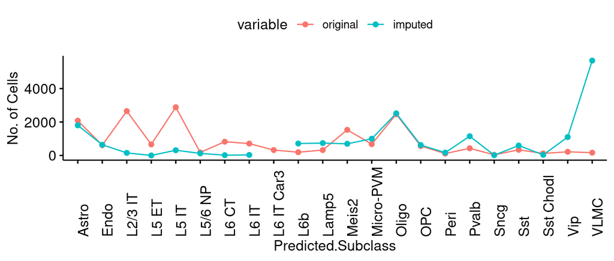

Thus, we can conclude that while the guesswork made by ATAC-Seq sounds fascinating, when compared to original RNASeq it could be too-divergent, can’t be seen as replacement of biological replicates, suffer compositional bias and might require integration with original RNAseq if any downstream analysis is being planned.